# Population genetic differences between warblers

Fiona Moss

### Summary:

According to my analysis, mean value of Fst is **0.01523262** and it is approximately three times the calculations presented in the research paper (**0.0045**). The uncertainty in the analysis has been quantified by considering the *95% credible interval* for the allele frequency which states that the true parameter lies in this interval with 95% confidence.

Since the Fst is an estimate of similarity not just within a species but also among various species, a higher Fst in the analysis indicates more difference between the Golden-wing warblers (GWWA) and the Blue-wing warblers (BWWA).

Finite sample size affects the estimate of p. Therefore, we draw random values from the model and propagate the uncertainty to Fst to quantify our uncertainty. The uncertainty in Fst reflects uncertainty in underlying allele frequencies.

In my analysis, I used the Bayesian Inference on a Binomial distribution which resulted in a Beta distribution. Then estimates of allele frequencies were transformed to Fst for each locus to quantify uncertainty.

The six regions of interest according to the research paper were plotted and their genomic regions around the highest Fst was plotted along with our findings of the genomic regions around the highest Fst. None of these regions matched indicating a significant difference between our estimates and the estimates reported in the research papers.

### Approach of the analysis:

1. Determining the appropriate distribution (Beta Distribution in our case) to model the allele data.
2. Finding the Bayes Estimate for the mean value.
3. Propagation of uncertainty to Fst to quantify uncertainty by drawing random samples from the model.
4. Comparison of this result with the result of the research paper.

### Analysis of Data:

The data for this study is present at the following location:

```r
#The file where the data related to warblers is located
warblers <- read.csv("order_warblers.csv")
#The file where the data related to genotypes is located
geno <- read.table("ddrad_geno.txt", stringsAsFactors = F)
#Loci
loci <- geno[,1]
#Genotype
geno <- geno[,-1]
```

To analyze the above data **Bayesian Analysis** is used since the data consists of discrete events (determining the presence of alleles) over discrete trails (discrete time space). Since we need to find the presence of a particular allele (reference allele) in the discrete trials, the data follows a **Binomial Distribution**.

Bayesian methods provide the posterior probability since they are used to provide the probability density of model parameters given the data. The probability distribution of the allele frequency will describe all information about the parameters and our uncertainty about the point estimates.

The formula for Bayes theorem for posterior probability is given by:
$$P(p|allele \hspace{0.2cm} data) = \dfrac{P(allele \hspace{0.2cm} data|p).P(p)}{P(allele \hspace{0.2cm} data)}$$

Here $P(p|data)$ is the posterior, $P(data|p)$ is the likelihood, $P(p)$ is the prior probability of p and $P(data)$ is the normalizing constant.

When a Bayesian model is applied to a binomial distribution (likelihood multiplied by prior probability), it results in a beta-binomial distribution. Since we do not know how the prior is distributed, a uniform Beta distribution was used to get accurate analytical results. The normalizing constant is not needed here mathematically. The desirable prior for a binomial is a beta distribution, because of their mathematical relationship (beta is conjugate prior to binomial). Therefore, Beta distribution was used to represent the allele frequencies.

To calculate the mean of the allele frequency, the count and size of reference alleles have been taken into consideration.

```r
# Count of reference alleles
x <- aggregate(t(geno),by = list(warblers$phenotype), sum, na.rm = T)
row.names(x) <- x[, 1]
x <- x[, -1]
# Size of reference alleles
n<-aggregate(t(geno), by = list(warblers$phenotype), function(x)sum(!is.na(x)))
row.names(n) <- n[, 1]
n <- n[, -1]
# Size multiplied by number of copies of alleles (Total number of trials)
n <- 2 * n
# Bayesian Estimate of Beta-Binomial Distribution
alpha <- as.matrix(x+1)
beta <- as.matrix(n-x+1)
#Mean/estimate of a Beta Distribution (Bayesian point estimate)
p.est.bayes <- alpha/(alpha+beta)
# Summary of allele frequency for BWWA and GWWA
summary(t(p.est.bayes[c(2,3),]))
```

```
      BWWA              GWWA
 Min.   :0.01667   Min.   :0.004386
 1st Qu.:0.05000   1st Qu.:0.039062
 Median :0.10000   Median :0.073864
 Mean   :0.22757   Mean   :0.215832
 3rd Qu.:0.28571   3rd Qu.:0.254762
 Max.   :0.98333   Max.   :0.994253
```

We need to transform estimates of allele frequencies to Fst for each locus.

```r
# Method for finding Hudson Fst
hudsonFst <- function(p1=NA, p2=NA, locusspecific=F){
  p1.comp <- 1 - p1
  p2.comp <- 1 - p2
  # H_w for numerator : p1 * p1.comp + p2 * p2.comp
  # H_b for denominator: p1 * p2.comp + p2 * p1.comp
  # 1 - numerator/denominator # Hudsons's Fst
  if(locusspecific==T){
  # return fst for each locus
      return(1 - (p1 * p1.comp + p2 * p2.comp)/(p1 * p2.comp + p2 * p1.comp))
  }
  # return mean fst for set of loci
  mean(1 - (p1 * p1.comp + p2 * p2.comp)/(p1 * p2.comp + p2 * p1.comp))
}
```

Since we have to determine the genomic difference between populations of Golden-wing and Blue-wing warblers, we use Fst which provides us with the similarity among various species.

```r
# Bayesian Estimate of Fst
fst.p.est.bayes <- hudsonFst(p.est.bayes[2,], p.est.bayes[3,], locusspecific = T)
summary(fst.p.est.bayes)
```

```
    Min.  1st Qu.   Median     Mean  3rd Qu.     Max.
0.000000 0.001492 0.006708 0.015230 0.019040 0.307200
```

```r
mean(fst.p.est.bayes)
```

```
[1] 0.01523262
```

```r
# hist(fst.p.est.bayes)
```

We found the mean to be **0.0152326** which is three times higher than the findings of the authors.

We need to take the loci apart and split by loci into chromosome location and base pair location.

```r
# Splitting the loci into scaffold and position (bp)
position <- matrix(unlist(strsplit(loci, ":")),ncol = 2, byrow = T)
position <- data.frame(scaffold = as.character(position[,1]),bp = position[,2], stringsAsFactors = F)
```

Generally, allele frequency changes due to the following reasons:  
1. Natural Selection, Mutation, Migration/gene-flow  
2. There is variability in the evolution rate among loci

Since finite sample size affects the estimate of p, random values were drawn from the model and the uncertainty was propagated to Fst to quantify our uncertainty.

```r
### use beta distribution of allele frequencies at a locus
### to propogate uncertainty to estimate of Fst at each locus
### by drawing random samples from each species' beta distribution
sim.p.quantiles<-matrix(0, nrow=length(loci), ncol=2)
for(locus in 1:length(loci)){
  sim.p.bwwa<-rbeta(1000, alpha[2,locus], beta[2,locus])
  sim.p.gwwa<-rbeta(1000, alpha[3,locus], beta[3,locus])
  sim.p.quantiles[locus,]<-quantile(hudsonFst(sim.p.bwwa, sim.p.gwwa, locusspecific=T),
                                    probs=c(0.025, 0.975))
}
# summary of the first quanitile
summary(sim.p.quantiles[,1])
```

```
     Min.   1st Qu.    Median      Mean   3rd Qu.      Max.
2.260e-06 1.657e-05 2.874e-05 5.113e-04 6.755e-05 1.269e-01
```

```r
# summary of the third quantile
summary(sim.p.quantiles[,2])
```

```
   Min. 1st Qu.  Median    Mean 3rd Qu.    Max.
0.03376 0.06090 0.08328 0.09775 0.11890 0.52130
```

```r
# Graph to represent the uncertainity of Fst in each locus
X <- sim.p.quantiles
h <- hist(X, breaks = 20, col = "grey", xlab = "Fst", main = "Uncertainity of Fst in each locus")
# Sequence of numbers between min(sim.p.quantiles) and max(sim.p.quantiles)
xfit<-seq(min(X),max(X),length=40)
# Normal distribution of the min and max values
yfit<-dnorm(xfit,mean=mean(X),sd=sd(X))
yfit <- yfit*diff(h$mids[1:2])*length(X)
lines(xfit, yfit, col="green", lwd=2)
```

```r
# Mean as per the research paper
abline(v = 0.0045, col = "blue")
# Mean as per our analysis
abline(v = mean(fst.p.est.bayes), col = "red")
```

```r
# Mean of the first quantile
abline(v = mean(sim.p.quantiles[,1]))
# Mean of the third quantile
abline(v = mean(sim.p.quantiles[,2]))
```

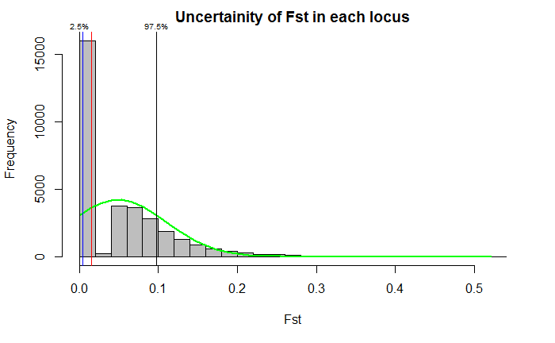

```r
# Text above the first quantile
mtext(text = "2.5%", side = 3, at = mean(sim.p.quantiles[,1]), las = 1, cex = 0.6)
# Text above the third quantile
mtext(text = "97.5%", side = 3, at = mean(sim.p.quantiles[,2]), las = 1, cex = 0.6)
```

Plotting the six regions of interest as per the research paper we get the following graphs:

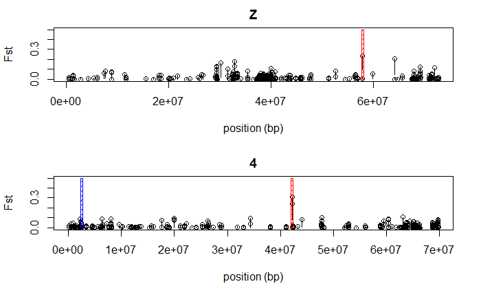

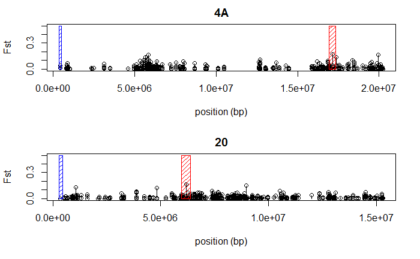

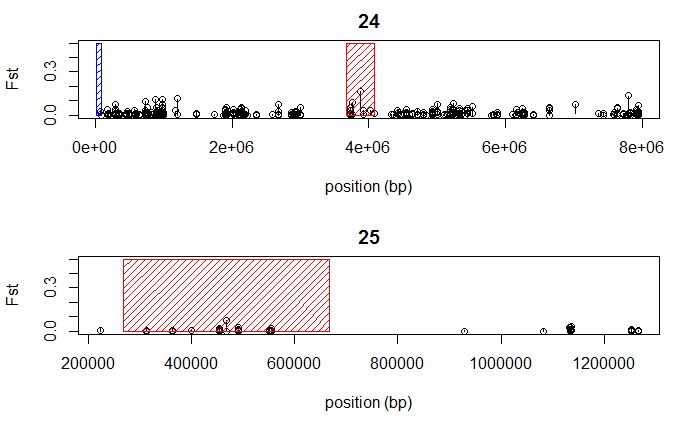

```r
# Code to plot the six regions of interest of the research paper.
# Binding the position with the bayes estimate
fst_pos <- cbind(position, fst.p.est.bayes)
par(mfrow=c(2,1))
for(i in c("Z", "4", "4A", "20", "24", "25")){
  plot(as.numeric(position$bp[position$scaffold == i]),
     fst.p.est.bayes[position$scaffold == i],
     ylim = c(0,0.5), main = i, xlab = "position (bp)",
     ylab = "Fst")
  # Finding the position of the maximum bayesian estimate
  segments(as.numeric(position$bp[position$scaffold == i]), sim.p.quantiles[position$scaffold == i, 1],
           as.numeric(position$bp[position$scaffold == i]), sim.p.quantiles[position$scaffold == i, 2])
  # Plotting the shaded area of the reasearch paper
  if (i == "4") {
    rect(xleft = 2300000, xright = 2700000, ybottom = 0, ytop = 0.5, density = 20, col = "blue")
  }
  else if (i == "4A") {
    rect(xleft = 350000, xright = 500000, ybottom = 0, ytop = 0.5, density = 20, col = "blue")
  }
  else if (i == "20") {
    rect(xleft = 300000, xright = 450000, ybottom = 0, ytop = 0.5, density = 20, col = "blue")
  }
  else if (i == "24") {
    rect(xleft = 10000, xright = 80000, ybottom = 0, ytop = 0.5, density = 20, col = "blue")
  }
  i_fst <- fst_pos[position$scaffold == i,]
  max_fst <- i_fst[i_fst$fst.p.est.bayes == max(i_fst$fst.p.est.bayes),]

  rect(xleft = as.numeric(max_fst$bp)-200000, xright = as.numeric(max_fst$bp)+200000, ybottom = 0, ytop = 0.5, density = 20, col = "red")
}
```

The red shaded area represents the genomic region around the highest Fst according to our analysis and the blue shaded area represents the genomic region around the highest Fst calculated in the research paper. Hence, it is clear that both the regions do not match indicating a major difference between our estimates and the research paper’s estimates.

### Extent of differences between our study and the study presented in the research paper:

In the research paper, only the measure of Fst was given. Information about the analysis was not included. Whereas in our study, we have quantified our uncertainty and built a model to sample the data. Therefore, there is a higher possibility of our results being more accurate than the results of the research paper.

In conclusion, though there is a major difference between the estimates (nearly threefold), the estimates themselves are very small and are not sufficient to determine the population genome differentiation of golden-wing and blue-wing warblers. Therefore, though we agree with the research paper about the warblers being quite similar, there is a difference in our analysis and estimate values.